# Modern Data Mining, HW 3

Etienne Lee

Sung Cho

Leo Li

Due 11:59 pm, 03/22, 2026

# 1 PartI: Model Building

Multiple regression is one of the most popular methods used in statistics as well as in machine learning. We use linear models as a working model for its simplicity and interpretability. It is important that we use domain knowledge as much as we could to determine the form of the response as well as the function format for the factors. Then, when we have many possible features to be included in the working model it is inevitable that we need to choose a best possible model with a sensible criterion. Regularizations such as LASSO are introduced. Be aware that if a model selection is done formally or informally, the inferences obtained with the final `lm()` fit may not be valid. Some adjustment will be needed. This last step is beyond the scope of this class. Check the research line that Linda and collaborators have been working on.

The main job in this part is a rather involved case study about devastating covid19 pandemic. Please read through the case study first. This project is for sure a great one listed in your CV.

For covid case study, the major time and effort would be needed in EDA portion.

## 1.1 Objectives

- Model building process
- Methods
  - Model selection
    - LASSO (L1 penalty)
    - A quick backward elimination
- Understand the criteria
  - Testing Errors
  - `K fold Cross Validation`
  - `LASSO`
- Packages
  - `lm()`, `Anova`
  - `glmnet()` & `cv.glmnet()`
  - coefplot::extract.coef()

## 1.2 Review materials

- Study lecture: Regularization
- Study lecture: Multiple regression

Review the code and concepts covered during lectures: multiple regression, penalized regression through elastic net (only LSASSO).

**Important Notice:** The focus of this part is Covid case study.

## 1.3 Case study: COVID19

See a seperate file covid_case_study_2026.Rmd for details.

- Start the EDA as earlier as possible.
- Please check previous midterms where we used the same dataset.

# 2 Part II: Logistic Regression

Logistic regression is used for modeling categorical response variables. The simplest scenario is how to identify risk factors of heart disease? In this case the response takes a possible value of `YES` or `NO`. Logit link function is used to connect the probability of one being a heart disease with other potential risk factors such as `blood pressure`, `cholestrol level`, `weight`. Maximum likelihood function is used to estimate unknown parameters. Inference is made based on the properties of MLE. We use AIC to help nailing down a useful final model. Predictions in categorical response case is also termed as `Classification` problems. One immediately application of logistic regression is to provide a simple yet powerful classification boundaries. Various metrics/criteria are proposed to evaluate the quality of a classification rule such as `False Positive`, `FDR` or `Mis-Classification Errors`.

LASSO with logistic regression is a powerful tool to get dimension reduction. We will not use it here in this work.

## 2.1 Objectives

- Understand the model
  - logit function
    - interpretation
  - Likelihood function
- Methods
  - Maximum likelihood estimators
    - Z-intervals/tests
    - Chi-squared likelihood ratio tests
- Metrics/criteria
  - Sensitivity/False Positive
  - True Positive Prediction/FDR
  - Misclassification Error/Weighted MCE
  - Residual deviance
  - Training/Testing errors
- R functions/Packages
  - `glm()`, `Anova`
  - `pROC`
- Data needed
  - `Framingham.dat`

## 2.2 R Markdown / Knitr tips

You should think of this R Markdown file as generating a polished report, one that you would be happy to show other people (or your boss). There shouldn’t be any extraneous output; all graphs and code run should clearly have a reason to be run. That means that any output in the final file should have explanations.

A few tips:

- Keep each chunk to only output one thing! In R, if you’re not doing an assignment (with the `<-` operator), it’s probably going to print something.
- If you don’t want to print the R code you wrote (but want to run it, and want to show the results), use a chunk declaration like this: `{r, echo=F}`. Notice this is set as a global option.
- If you don’t want to show the results of the R code or the original code, use a chunk declaration like: `{r, include=F}`
- If you don’t want to show the results, but show the original code, use a chunk declaration like: `{r, results='hide'}`.
- If you don’t want to run the R code in a chunk at all use `{r, eval = F}`.
- We show a few examples of these options in the below example code.
- For more details about these R Markdown options, see the [documentation](http://yihui.name/knitr/options/).
- Delete the instructions and this R Markdown section, since they’re not part of your overall report.

## 2.3 Review

Review the code and concepts covered in

- Module Logistic Regressions/Classification

## 2.4 Framingham heart disease study

We will continue to use the Framingham Data (`Framingham.dat`) so that you are already familiar with the data and the variables. All the results are obtained through training data.

Liz is a patient with the following readings: `AGE=50, GENDER=FEMALE, SBP=110, DBP=80, CHOL=180, FRW=105, CIG=0`. We would be interested to predict Liz’s outcome in heart disease.

To keep our answers consistent, use a subset of the data, and exclude anyone with a missing entry. For your convenience, we’ve loaded it here together with a brief summary about the data.

We note that this dataset contains 311 people diagnosed with heart disease and 1095 without heart disease.

```
     0    1
  1095  311
```

Lastly we would like to show five observations randomly chosen.

```
      HD AGE    SEX SBP DBP CHOL FRW CIG
  643  1  61   MALE 140  68  248 104  20
  11   0  45   MALE 110  88  183  90   0
  576  1  58   MALE 150  95  296 100  15
  560  1  59   MALE 260 130  246 111  20
  702  0  45 FEMALE 122  74  178  88   5
```

### 2.4.1 Identify risk factors

#### 2.4.1.1 Understand the likelihood function

Conceptual questions to understand the building blocks of logistic regression. All the codes in this part should be hidden. We will use a small subset to run a logistic regression of `HD` vs. `SBP`.

1. Take a random subsample of size 5 from `hd_data_f` which only includes `HD` and `SBP`. Also set `set.seed(471)`. List the five observations neatly below. No code should be shown here.
2. Write down the likelihood function using the five observations above.

$$(y_i, x_i) =
(1,140),\ (0,110),\ (1,150),\ (1,260),\ (0,122).$$

$$L(\beta_0, \beta_1)
=
\frac{e^{\beta_0 + 140\beta_1}}{1 + e^{\beta_0 + 140\beta_1}}
\cdot
\frac{1}{1 + e^{\beta_0 + 110\beta_1}}
\cdot
\frac{e^{\beta_0 + 150\beta_1}}{1 + e^{\beta_0 + 150\beta_1}}
\cdot
\frac{e^{\beta_0 + 260\beta_1}}{1 + e^{\beta_0 + 260\beta_1}}
\cdot
\frac{1}{1 + e^{\beta_0 + 122\beta_1}}.$$

3. Find the MLE based on this subset using glm(). Report the estimated logit function of `SBP` and the probability of `HD`=1. Briefly explain how the MLE are obtained based on ii. above.

Using the subsample, we fit a logistic regression model of the form:

log(p(x) / (1 - p(x))) = β₀ + β₁ x,

where x = SBP.

Using glm(), the estimated coefficients are:

β̂₀ = -334.96, β̂₁ = 2.56.

The maximum likelihood estimates are obtained by maximizing the likelihood function from part (ii), which is:

L(β₀, β₁) = ∏ pᵢ^{yᵢ} (1 - pᵢ)^{1 - yᵢ}.

Equivalently, glm() maximizes the log-likelihood:

ℓ(β₀, β₁) = Σ [ yᵢ(β₀ + β₁ xᵢ) − log(1 + exp(β₀ + β₁ xᵢ)) ].

Since no closed-form solution exists, the estimates are obtained numerically using an iterative optimization procedure (iteratively reweighted least squares).

#### 2.4.1.2 Identify important risk factors for `Heart.Disease.`

We focus on understanding the elements of basic inference method in this part. Let us start a fit with just one factor, `SBP`, and call it `fit1`. We then add one variable to this at a time from among the rest of the variables. For example

1. Which single variable would be the most important to add? Add it to your model, and call the new fit `fit2`.  
   From the candidate models, adding AGE to the model with SBP results in: a large reduction in residual deviance (from 1417.5 → 1400.8), a highly significant coefficient for AGE (p-value = 4.9 × 10⁻⁵), and a lower AIC (1421 → 1407). Therefore, AGE is the most important variable to add.

2. Is the residual deviance of `fit2` always smaller than that of `fit1`? Why or why not? Yes — for this setup, the residual deviance of fit2 is always less than or equal to that of fit1.

This is because fit2 is a nested model that contains all the terms in fit1 plus one additional predictor. Since fit1 is a special case of fit2, the larger model has a bigger parameter space. When glm() fits the model by maximum likelihood, optimizing over a larger set of possible parameter values cannot give a worse maximized likelihood than optimizing over a smaller set.

Because residual deviance is defined as

residual deviance = -2 × (maximized log-likelihood) up to the same constant,

a larger maximized log-likelihood means a smaller (or equal) residual deviance. Therefore,

Deviance(fit2) ≤ Deviance(fit1).

3. Perform both the Wald test and the Likelihood ratio tests (Chi-Squared) to see if the added variable is significant at the .01 level. What are the p-values from each test? Are they the same?

From the summary of fit2, the Wald test p-value for AGE is: p-value (Wald) = 4.9 × 10⁻⁵. From the likelihood ratio test comparing fit1 and fit2, the deviance difference is: 1417 − 1401 = 16.7, with 1 degree of freedom, giving: p-value (LRT) = 4.4 × 10⁻⁵.

#### 2.4.1.3 Model building

Start with all variables. Our goal is to fit a well-fitting model, that is still small and easy to interpret (parsimonious).

1. Use backward selection method. Only keep variables whose coefficients are significantly different from 0 at .05 level. Kick out the variable with the largest p-value first, and then re-fit the model to see if there are other variables you want to kick out.

We begin with the full model:

HD ~ AGE + SEX + SBP + DBP + CHOL + FRW + CIG.

In the first step, DBP has the largest p-value (0.706), which is greater than 0.05, so we remove DBP and refit the model.

After removing DBP, we refit the model. In this updated model, FRW has the largest p-value (0.1315), which is greater than 0.05. Therefore, we remove FRW and refit the model.

After removing FRW, we refit the model. In this model, CIG has the largest p-value (0.0608), which is greater than 0.05. Therefore, we remove CIG and refit the model.

The final model after backward selection is: HD ~ AGE + SEX + SBP + CHOL.

2. Use AIC as the criterion for model selection. Find a model with small AIC through exhaustive search. Does exhaustive search guarantee that the p-values for all the remaining variables are less than .05? Is our final model here the same as the model from backwards elimination?

No, AIC-based model selection does not guarantee that all remaining variables have p-values less than 0.05. In this case, the variable FRW has a p-value of 0.1315, which is greater than 0.05, yet it remains in the model. This is because AIC focuses on optimizing the trade-off between model fit and model complexity, rather than testing statistical significance of individual coefficients.

3. Use the model chosen from part ii. as the final model. Write a brief summary to describe important factors relating to Heart Diseases (i.e. the relationships between those variables in the model and heart disease). Give a definition of “important factors”. Using the AIC-selected model: HD ~ AGE + SEX + SBP + CHOL + FRW + CIG,

we summarize the important factors related to heart disease. An “important factor” is defined as a variable that contributes meaningfully to predicting heart disease risk in the model, either by being statistically significant or by improving overall model fit (as measured by AIC).

From the fitted model: AGE has a positive coefficient, indicating that older individuals have higher odds of developing heart disease. SEX (male) has a positive coefficient, suggesting that males have higher odds of heart disease compared to females. SBP (systolic blood pressure) has a positive coefficient, meaning higher blood pressure is associated with increased heart disease risk. CHOL (cholesterol) also has a positive effect, indicating that higher cholesterol levels increase the likelihood of heart disease. CIG (cigarette usage) has a positive coefficient, suggesting that smoking is associated with increased heart disease risk. FRW has a positive coefficient but is not statistically significant at the 0.05 level; however, it is retained in the model because it contributes to improving overall model fit under the AIC criterion.

### 2.4.2 Classification analysis

#### 2.4.2.1 ROC/FDR

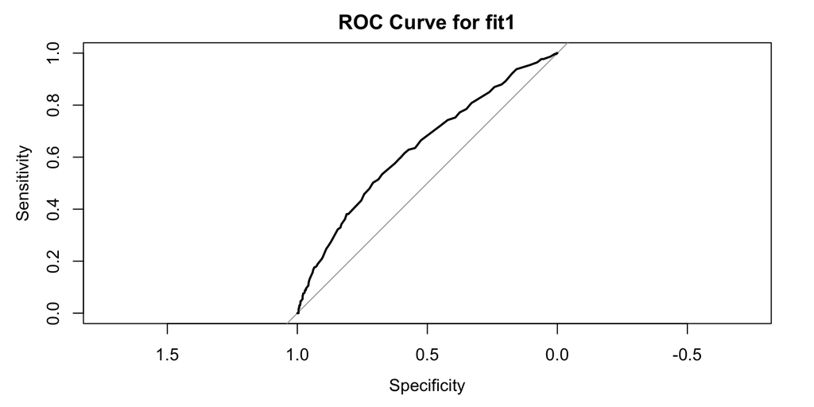

2. Overlay two ROC curves: one from `fit1`, the other from `fit2`. Does one curve always contain the other curve? Is the AUC of one curve always larger than the AUC of the other one? Why or why not?

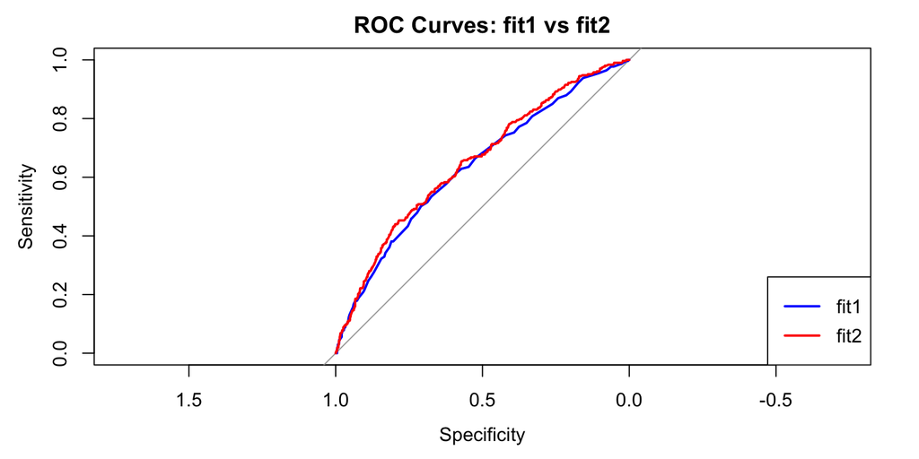

No, one ROC curve does not necessarily dominate the other. The curves may cross each other, meaning either one model performs better at low FPR regions or the other performs better at high FPR regions. This happens because each model produces different probability rankings, and ROC curves depend on the ordering of predicted probabilities, not just model complexity. And no, the AUC of one model is not guaranteed to be larger than the other. Even though fit2 includes more variables than fit1, this does not guarantee better out-of-sample ranking performance AUC depends on how well the model separates positives from negatives, not just goodness of fit

3. Estimate the Positive Prediction Values and Negative Prediction Values for `fit1` and `fit2` using .5 as a threshold. Which model is more desirable if we prioritize the Positive Prediction values?

If we prioritize Positive Predictive Value, we prefer fit2 since PPVfit2 = 0.5 > 0.45 = PPVfit1

4. For `fit1`: overlay two curves, but put the threshold over the probability function as the x-axis and positive prediction values and the negative prediction values as the y-axis. Overlay the same plot for `fit2`. Which model would you choose if the set of positive and negative prediction values are the concerns? If you can find an R package to do so, you may use it directly.

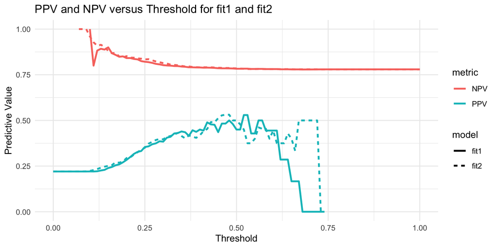

#### 2.4.2.2 Cost function/ Bayes Rule

Bayes rules with risk ratio $\frac{a_{10}}{a_{01}}=10$ or $\frac{a_{10}}{a_{01}}=1$. Use your final model obtained from Part 1 to build a class of linear classifiers.

1. Write down the linear boundary for the Bayes classifier if the risk ratio of $a_{10}/a_{01}=10$.

Decision rule: Predict HD = 1 if the left-hand side > 2.3026, otherwise predict HD = 0.

Now, draw two estimated curves where x = threshold, and y = misclassification errors, corresponding to the thresholding rule given in x-axis.

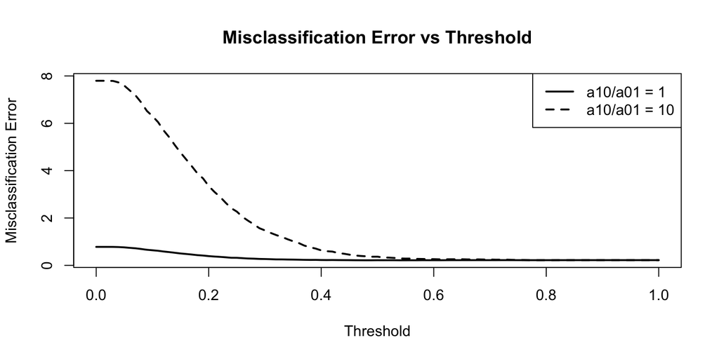